# BinarySVMXHT: Create Support Vector Machine (SVM) Binary Classification Model with Hypothesis Testing Validation

Vincent, Boer 123040049@link.cuhk.edu.cn and Adrian, Kristanto 123040001@link.cuhk.edu.cn

## Setup

In this documentation, the “StudentDepressionDataset.csv” will be used to provide demonstrations of the functions. First, let’s have a look at the dataset.

```r
library(BinarySVMXHT)

dataset = student_depression_dataset
names(dataset)
```

```
#>  [1] "id"
#>  [2] "Gender"
#>  [3] "Age"
#>  [4] "City"
#>  [5] "Profession"
#>  [6] "Academic.Pressure"
#>  [7] "Work.Pressure"
#>  [8] "CGPA"
#>  [9] "Study.Satisfaction"
#> [10] "Job.Satisfaction"
#> [11] "Sleep.Duration"
#> [12] "Dietary.Habits"
#> [13] "Degree"
#> [14] "Have.you.ever.had.suicidal.thoughts.."
#> [15] "Work.Study.Hours"
#> [16] "Financial.Stress"
#> [17] "Family.History.of.Mental.Illness"
#> [18] "Depression"
```

```r
head(dataset, 6)
```

```
#>   id Gender Age          City Profession Academic.Pressure Work.Pressure CGPA
#> 1  2   Male  33 Visakhapatnam    Student                 5             0 8.97
#> 2  8 Female  24     Bangalore    Student                 2             0 5.90
#> 3 26   Male  31      Srinagar    Student                 3             0 7.03
#> 4 30 Female  28      Varanasi    Student                 3             0 5.59
#> 5 32 Female  25        Jaipur    Student                 4             0 8.13
#> 6 33   Male  29          Pune    Student                 2             0 5.70
#>   Study.Satisfaction Job.Satisfaction    Sleep.Duration Dietary.Habits  Degree
#> 1                  2                0         5-6 hours        Healthy B.Pharm
#> 2                  5                0         5-6 hours       Moderate     BSc
#> 3                  5                0 Less than 5 hours        Healthy      BA
#> 4                  2                0         7-8 hours       Moderate     BCA
#> 5                  3                0         5-6 hours       Moderate  M.Tech
#> 6                  3                0 Less than 5 hours        Healthy     PhD
#>   Have.you.ever.had.suicidal.thoughts.. Work.Study.Hours Financial.Stress
#> 1                                   Yes                3                1
#> 2                                    No                3                2
#> 3                                    No                9                1
#> 4                                   Yes                4                5
#> 5                                   Yes                1                1
#> 6                                    No                4                1
#>   Family.History.of.Mental.Illness Depression
#> 1                               No          1
#> 2                              Yes          0
#> 3                              Yes          0
#> 4                              Yes          1
#> 5                               No          0
#> 6                               No          0
```

## Data Preprocessing

Before data preprocessing, it is helpful to have a look at the distribution of the data to understand the data and decide which features are useful in creating a model. The `plot_hist` function can be used to plot the histogram of feature columns in the data. For example:

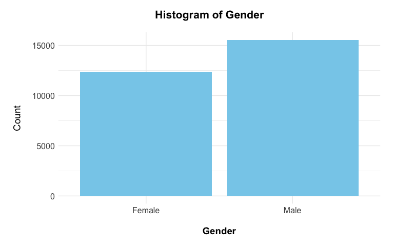

```r
plot_hist(dataset, "Gender")
```

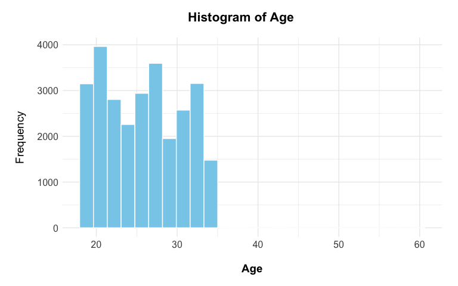

```r
plot_hist(dataset, "Age")
```

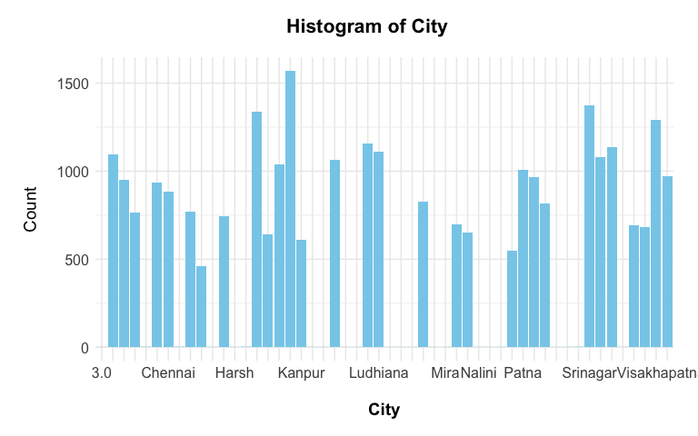

```r
plot_hist(dataset, "City")
```

Or if all feature columns needed to be plot:

```r
lapply(names(dataset), function(x) {
  plot_hist(dataset, x)
})
```

After looking at the data overview, we can begin to process the data. Feature columns with no variety such as “Profession”, “Job.Satisfaction”, and “Work.Pressure” can be removed manually. The same goes for the “id” column which is irrelevant to the label.

```r
dataset = dataset[, -which(names(dataset) %in% c("id", "Profession", "Job.Satisfaction", "Work.Pressure"))]
```

```r
# Create a list which maps the character feature columns to numeric.
mapping = list(Gender = c("Female", "Male"),
                 Sleep.Duration = c("Less than 5 hours", "5-6 hours", "7-8 hours", "More than 8 hours", "Others"),
                 Dietary.Habits = c("Unhealthy", "Moderate", "Healthy"),
                 Have.you.ever.had.suicidal.thoughts.. = c("No", "Yes"),
                 Family.History.of.Mental.Illness = c("No", "Yes"))

dataset = preprocess(dataset, mapping, "Depression")

head(dataset, 6)
```

```
#>   Gender Age Academic.Pressure CGPA Study.Satisfaction Sleep.Duration
#> 1      1  33                 5 8.97                  2              2
#> 2      0  24                 2 5.90                  5              2
#> 3      1  31                 3 7.03                  5              1
#> 4      0  28                 3 5.59                  2              3
#> 5      0  25                 4 8.13                  3              2
#> 6      1  29                 2 5.70                  3              1
#>   Dietary.Habits Have.you.ever.had.suicidal.thoughts.. Work.Study.Hours
#> 1              3                                     1                3
#> 2              2                                     0                3
#> 3              3                                     0                9
#> 4              2                                     1                4
#> 5              2                                     1                1
#> 6              3                                     0                4
#>   Financial.Stress Family.History.of.Mental.Illness Depression
#> 1                1                                0          1
#> 2                2                                1         -1
#> 3                1                                1         -1
#> 4                5                                1          1
#> 5                1                                0         -1
#> 6                1                                0         -1
```

The `preprocess` function automatically removes any rows with NA values and columns with unconverted character values for simplicity. It also name unnamed columns, as column names will be needed for some later functions. With the dataset now consist of only numeric feature columns and -1 and 1 label, it can now be used to train SVM models.

## SVM Model Training

The `svm` function takes numeric features and label data, and returns a list of values which represents the SVM model.

```r
data = dataset[, 1:11]
label = dataset[, 12]
linear.model = svm(data[1:250, ], label[1:250])
linear.model
```

```
#> $w
#>                                Gender                                   Age
#>                           -0.15378447                           -0.24522901
#>                     Academic.Pressure                                  CGPA
#>                            0.83868983                            0.42868752
#>                    Study.Satisfaction                        Sleep.Duration
#>                           -0.07613749                           -0.05947119
#>                        Dietary.Habits Have.you.ever.had.suicidal.thoughts..
#>                           -0.06639901                            0.98680014
#>                      Work.Study.Hours                      Financial.Stress
#>                            0.07648197                            0.64484694
#>      Family.History.of.Mental.Illness
#>                            0.07882631
#>
#> $b
#> [1] 0.2056443
#>
#> $type
#> [1] "linear"
#>
#> $features
#>  [1] "Gender"
#>  [2] "Age"
#>  [3] "Academic.Pressure"
#>  [4] "CGPA"
#>  [5] "Study.Satisfaction"
#>  [6] "Sleep.Duration"
#>  [7] "Dietary.Habits"
#>  [8] "Have.you.ever.had.suicidal.thoughts.."
#>  [9] "Work.Study.Hours"
#> [10] "Financial.Stress"
#> [11] "Family.History.of.Mental.Illness"
```

We can also decide to use random index of the data and choose feature columns for the model.

```r
linear.model.partial = svm(data, label, n = 250, features = names(data)[1:8])
linear.model.partial
```

```
#> $w
#>                                Gender                                   Age
#>                           0.241450321                          -0.500849942
#>                     Academic.Pressure                                  CGPA
#>                           1.027111706                          -0.005464109
#>                    Study.Satisfaction                        Sleep.Duration
#>                          -0.412113990                           0.084705021
#>                        Dietary.Habits Have.you.ever.had.suicidal.thoughts..
#>                          -0.201348076                           0.841655509
#>
#> $b
#> [1] 0.629485
#>
#> $type
#> [1] "linear"
#>
#> $features
#> [1] "Gender"
#> [2] "Age"
#> [3] "Academic.Pressure"
#> [4] "CGPA"
#> [5] "Study.Satisfaction"
#> [6] "Sleep.Duration"
#> [7] "Dietary.Habits"
#> [8] "Have.you.ever.had.suicidal.thoughts.."
```

In addition to linear SVM, polynomial and rbf kernels are also supported in the `svm` function.

```r
poly.model = svm(data, label, type = "polynomial", n = 250)

rbf.model = svm(data, label, type = "rbf", n = 250)
```

## Prediction and Accuracy Test

The models can be used to predict new data using the `predict` function. The accuracy of the prediction can be directly evaluted using the `test_accuracy` function.

```r
random.test.index = sample(1:nrow(data), size = 250, replace = FALSE)

predict(linear.model, data[random.test.index, ])
```

```
#>   [1]  1 -1 -1 -1  1 -1  1 -1 -1 -1  1 -1  1  1 -1  1 -1 -1  1 -1 -1  1 -1 -1 -1
#>  [26]  1 -1  1  1 -1  1 -1 -1 -1 -1  1  1 -1  1  1 -1 -1  1 -1 -1 -1  1  1  1  1
#>  [51]  1 -1  1 -1  1  1  1  1 -1 -1 -1  1  1 -1  1 -1 -1 -1  1  1  1  1  1 -1 -1
#>  [76]  1 -1  1  1 -1 -1  1 -1  1  1 -1 -1  1 -1 -1  1 -1  1  1  1 -1  1  1 -1 -1
#> [101] -1 -1 -1  1  1  1 -1  1  1  1  1 -1 -1  1  1  1  1 -1 -1 -1  1  1  1 -1 -1
#> [126]  1 -1 -1  1  1 -1  1  1 -1  1  1  1 -1  1  1 -1 -1 -1 -1  1 -1  1  1  1  1
#> [151]  1 -1  1  1  1  1 -1  1  1  1 -1  1 -1  1 -1 -1 -1 -1  1 -1  1  1  1  1 -1
#> [176] -1 -1 -1 -1  1  1  1 -1 -1  1 -1  1 -1  1 -1 -1 -1  1  1  1 -1 -1 -1 -1 -1
#> [201] -1  1 -1 -1  1  1  1  1 -1  1  1  1  1 -1  1  1  1  1  1 -1  1  1 -1 -1  1
#> [226]  1  1 -1  1 -1  1  1  1  1  1 -1 -1  1 -1 -1  1  1  1  1 -1  1  1  1  1  1
```

```r
test_accuracy(linear.model, data[random.test.index, ], label[random.test.index])
```

```
#> [1] 0.82
```

```r
predict(linear.model.partial, data[random.test.index, ])
```

```
#>   [1]  1  1 -1 -1  1 -1  1 -1 -1  1  1 -1 -1  1 -1  1 -1  1  1 -1  1  1 -1 -1  1
#>  [26]  1 -1  1  1 -1  1 -1 -1 -1 -1  1  1 -1  1  1 -1 -1 -1  1 -1 -1  1 -1  1  1
#>  [51]  1  1  1 -1 -1  1  1  1 -1 -1  1  1  1  1  1 -1  1  1 -1  1  1  1  1 -1 -1
#>  [76]  1 -1  1  1 -1  1  1 -1  1  1 -1  1  1 -1 -1  1 -1  1 -1 -1  1  1  1 -1  1
#> [101] -1  1 -1  1  1  1 -1  1  1  1  1  1 -1  1  1  1  1 -1  1 -1  1  1  1 -1  1
#> [126]  1 -1 -1  1  1 -1  1 -1 -1  1  1  1  1  1  1 -1  1  1 -1 -1 -1  1  1  1 -1
#> [151]  1 -1  1  1  1  1 -1  1  1  1 -1  1 -1  1 -1 -1 -1 -1  1 -1  1  1  1  1 -1
#> [176] -1  1  1 -1  1  1  1  1 -1  1 -1  1 -1 -1 -1 -1 -1  1  1  1  1 -1 -1 -1 -1
#> [201] -1  1  1 -1  1  1  1  1 -1  1  1  1  1 -1  1  1 -1  1  1  1  1  1  1  1  1
#> [226]  1  1 -1 -1 -1  1  1  1  1 -1 -1 -1  1 -1 -1  1 -1  1  1 -1  1  1  1  1  1
```

```r
test_accuracy(linear.model.partial, data[random.test.index, ], label[random.test.index])
```

```
#> [1] 0.728
```

```r
predict(poly.model, data[random.test.index, ])
```

```
#>   [1] -1 -1 -1 -1 -1 -1 -1 -1 -1 -1 -1 -1 -1  1 -1 -1 -1 -1 -1 -1 -1  1 -1  1 -1
#>  [26] -1 -1 -1 -1 -1 -1 -1 -1 -1 -1 -1  1 -1 -1 -1 -1 -1 -1 -1  1 -1 -1  1  1  1
#>  [51] -1 -1  1 -1 -1 -1  1  1 -1 -1  1 -1 -1 -1 -1 -1 -1 -1  1 -1 -1  1 -1 -1  1
#>  [76] -1 -1 -1  1 -1 -1 -1 -1  1  1 -1 -1  1 -1 -1  1 -1 -1 -1 -1 -1  1  1 -1 -1
#> [101] -1  1 -1 -1  1 -1 -1 -1 -1 -1 -1 -1 -1 -1 -1 -1 -1 -1  1 -1  1  1  1 -1 -1
#> [126]  1 -1 -1 -1 -1 -1  1 -1 -1 -1  1  1 -1 -1 -1  1 -1 -1 -1 -1 -1  1 -1  1  1
#> [151] -1 -1  1  1 -1  1 -1  1 -1 -1 -1 -1 -1 -1  1 -1 -1 -1 -1 -1 -1 -1 -1  1 -1
#> [176] -1 -1 -1 -1 -1  1 -1 -1 -1 -1 -1  1 -1  1 -1 -1 -1  1  1  1 -1 -1 -1 -1 -1
#> [201] -1 -1 -1 -1  1 -1 -1 -1 -1 -1 -1 -1 -1  1 -1  1  1 -1 -1 -1 -1  1 -1  1  1
#> [226]  1  1 -1 -1 -1 -1 -1 -1 -1 -1 -1 -1 -1 -1 -1 -1 -1 -1 -1 -1  1 -1  1 -1 -1
```

```r
test_accuracy(poly.model, data[random.test.index, ], label[random.test.index])
```

```
#> [1] 0.572
```

```r
predict(rbf.model, data[random.test.index, ])
```

```
#>   [1]  1 -1 -1 -1  1 -1  1 -1 -1 -1  1 -1  1  1 -1  1 -1  1  1  1  1  1 -1 -1  1
#>  [26]  1 -1  1  1  1  1 -1 -1 -1 -1  1  1 -1  1  1 -1 -1  1  1 -1  1  1 -1  1  1
#>  [51]  1 -1  1 -1  1  1  1  1 -1  1 -1  1  1  1  1 -1  1 -1  1  1  1  1  1 -1  1
#>  [76]  1 -1  1  1 -1  1  1 -1  1  1 -1  1  1 -1  1  1 -1  1  1  1  1  1  1  1 -1
#> [101] -1  1 -1  1  1  1 -1  1  1  1  1  1 -1  1  1  1  1 -1 -1 -1  1  1  1 -1 -1
#> [126]  1 -1 -1  1  1 -1  1 -1  1  1  1  1  1  1  1 -1  1 -1  1  1 -1  1  1  1  1
#> [151]  1 -1  1  1  1  1  1  1  1  1 -1  1  1  1 -1 -1 -1  1  1 -1  1  1  1  1 -1
#> [176] -1  1 -1 -1  1  1  1 -1 -1  1 -1  1 -1  1 -1 -1 -1  1  1  1  1  1 -1 -1  1
#> [201]  1  1 -1 -1  1  1  1  1 -1  1  1 -1  1  1  1  1  1  1  1  1  1  1 -1 -1  1
#> [226]  1  1 -1  1 -1  1  1  1  1 -1 -1 -1  1 -1 -1  1  1  1  1 -1  1  1  1  1  1
```

```r
test_accuracy(rbf.model, data[random.test.index, ], label[random.test.index])
```

```
#> [1] 0.804
```

## Feature Selection

In this example dataset, the number of features is small. However, in other datasets, number of features can be very large that feature selection should be done to improve model’s effectiveness and efficiency. This package provide `select_features` function to choose top “n” features if “n” is given, or all meaningful features where a feature is considered meaningful if it’s absolute correlation to the label is above some “min” value between 0 and 1.

```r
select_features(data, label, n =  8, show = TRUE)
```

```
#> Have.you.ever.had.suicidal.thoughts..                     Academic.Pressure
#>                           0.546411217                           0.474749563
#>                      Financial.Stress                                   Age
#>                           0.363717437                           0.226848012
#>                      Work.Study.Hours                        Dietary.Habits
#>                           0.208645073                           0.206752627
#>                    Study.Satisfaction                        Sleep.Duration
#>                           0.168092832                           0.087367966
#>      Family.History.of.Mental.Illness                                  CGPA
#>                           0.053608922                           0.022098814
#>                                Gender
#>                           0.001852643
#> [1] "Have.you.ever.had.suicidal.thoughts.."
#> [2] "Academic.Pressure"
#> [3] "Financial.Stress"
#> [4] "Age"
#> [5] "Work.Study.Hours"
#> [6] "Dietary.Habits"
#> [7] "Study.Satisfaction"
#> [8] "Sleep.Duration"
```

```r
select_features(data, label, min = 0.2)
```

```
#> [1] "Age"
#> [2] "Academic.Pressure"
#> [3] "Dietary.Habits"
#> [4] "Have.you.ever.had.suicidal.thoughts.."
#> [5] "Work.Study.Hours"
#> [6] "Financial.Stress"
```

## Parameter Tuning

The parameters for these kernels and the regularization parameter of the SVM can also be adjusted to improve the model. To choose the best parameter for a model, we can use the `tune_parameters` function which compares the performance of a model with different parameters.

```r
random.train.index = sample(1:nrow(data), size = 250, replace = FALSE)

tune_parameters(data[random.train.index, ], label[random.train.index],
               data[random.test.index, ], label[random.test.index], type = "linear", C = c(1, 10, 100))
```

```
#>     C training.accuracy test.accuracy
#> 1   1             0.864         0.796
#> 2  10             0.872         0.800
#> 3 100             0.868         0.800
```

```r
tune_parameters(data[random.train.index, ], label[random.train.index],
               data[random.test.index, ], label[random.test.index], type = "polynomial", C = c(1, 10, 100), degree = c(2, 3))
```

```
#>     C c degree training.accuracy test.accuracy
#> 1   1 1      2             0.784         0.660
#> 2   1 1      3             1.000         0.720
#> 3  10 1      2             0.696         0.636
#> 4  10 1      3             1.000         0.720
#> 5 100 1      2             0.720         0.636
#> 6 100 1      3             1.000         0.720
```

```r
tune_parameters(data[random.train.index, ], label[random.train.index],
               data[random.test.index, ], label[random.test.index], type = "rbf", C = c(1, 10, 100), gamma = c(0.05, 0.1, 0.2))
```

```
#>     C gamma training.accuracy test.accuracy
#> 1   1  0.05             0.920         0.804
#> 2   1  0.10             0.948         0.788
#> 3   1  0.20             0.968         0.788
#> 4  10  0.05             0.964         0.776
#> 5  10  0.10             1.000         0.756
#> 6  10  0.20             1.000         0.756
#> 7 100  0.05             1.000         0.728
#> 8 100  0.10             1.000         0.756
#> 9 100  0.20             1.000         0.756
```

Now that we have compared the parameters, we can retrain the model using more suitable parameters for better accuracy (while not always).

```r
random.test.index.2 = sample(1:nrow(data), size = 250, replace = FALSE)

linear.model.tuned = svm(data, label, type = "linear", n = 250, C = 10)
test_accuracy(linear.model.tuned, data[random.test.index.2, ], label[random.test.index.2])
```

```
#> [1] 0.848
```

```r
poly.model.tuned = svm(data, label, type = "polynomial", n = 250, degree = 3)
test_accuracy(poly.model.tuned, data[random.test.index.2, ], label[random.test.index.2])
```

```
#> [1] 0.648
```

```r
rbf.model.tuned = svm(data, label, type = "rbf", n = 250, C = 1, gamma = 0.2)
test_accuracy(rbf.model.tuned, data[random.test.index.2, ], label[random.test.index.2])
```

```
#> [1] 0.856
```

From the results, we can see that both rbf and linear models perform better compared to polynomial models. Thus, we will continue to evaluate the linear and rbf models.

## Model Evaluation

We can evaluate the accuracy of a model to an expected accuracy using hypothesis testing. For example, we want to check if “linear.model.tuned” actually has accuracy of above 80%. We can use the `hypo_test` function to evaluate this using Z-test or likelihood ratio test (LRT).

```r
linear.model.z.test = hypo_test(linear.model.tuned, data[random.test.index.2, ], label[random.test.index.2], 0.80, alternative = "greater", method = "z")
linear.model.lrt = hypo_test(linear.model.tuned, data[random.test.index.2, ], label[random.test.index.2], 0.80, alternative = "greater", method = "lrt")
linear.model.z.test$status
```

```
#> [1] "Reject null hypothesis"
```

```r
linear.model.lrt$status
```

```
#> [1] "Reject null hypothesis"
```

```r
rbf.model.z.test = hypo_test(rbf.model.tuned, data[random.test.index.2, ], label[random.test.index.2], 0.80, alternative = "greater", method = "z")
rbf.model.lrt = hypo_test(rbf.model.tuned, data[random.test.index.2, ], label[random.test.index.2], 0.80, alternative = "greater", method = "lrt")
rbf.model.z.test$status
```

```
#> [1] "Reject null hypothesis"
```

```r
rbf.model.lrt$status
```

```
#> [1] "Reject null hypothesis"
```

If one of the tests reject the null hypothesis, there is enough evidence that the model has accuracy of above 80%. In contrast, if both tests fails to reject the null hypothesis, there is not enough evidence that the model has accuracy of above 80%. To help understanding the test, we can plot the hypothesis testing results using `visualize_ht`. For Z-test, we can also plot the power function (1 - type II error) with respect to the possible true alternatives.

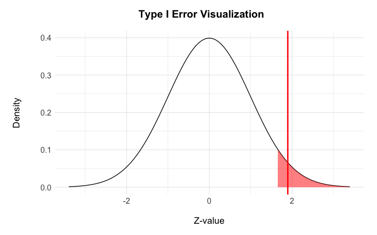

```r
visualize_ht(linear.model.z.test)
```

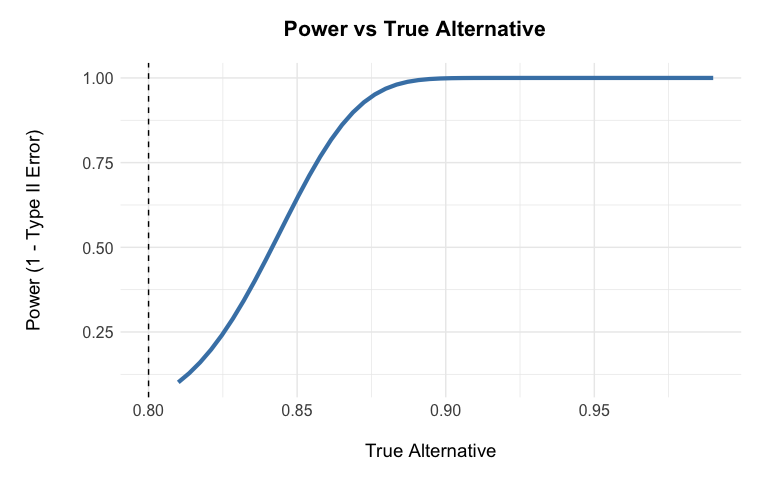

```r
visualize_ht(linear.model.z.test, type = "II")
```

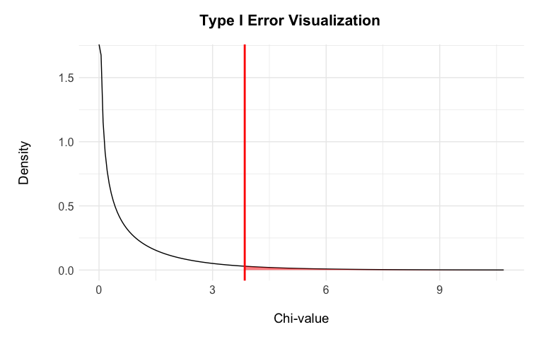

```r
visualize_ht(linear.model.lrt)
```

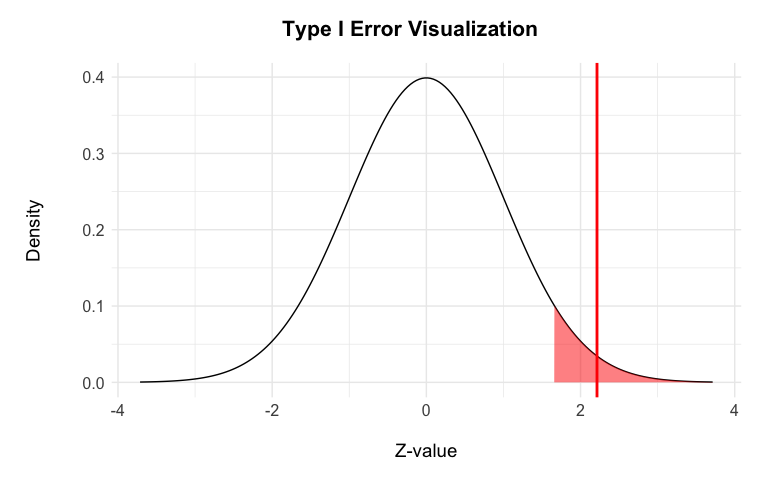

```r
visualize_ht(rbf.model.z.test)
```

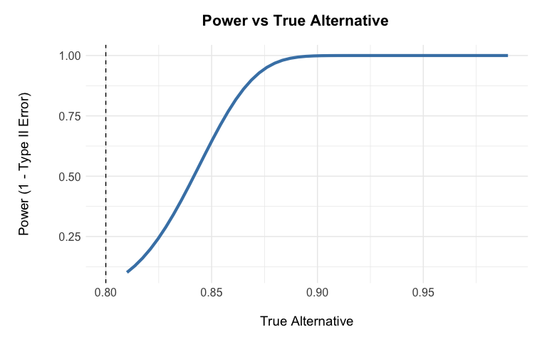

```r
visualize_ht(rbf.model.z.test, type = "II")
```

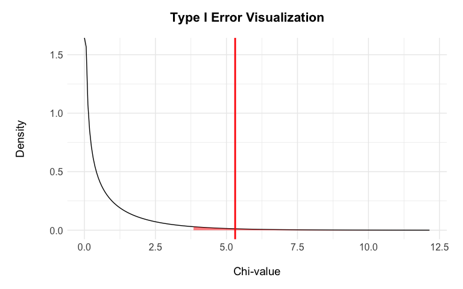

```r
visualize_ht(rbf.model.lrt)
```

## Advantages of this Package

- This is a beginner friendly package for those who want to learn data science. The documentation walk through a step-by-step workflow of support vector machine (SVM), but on a lower level compared to widely used package that handles everything automatically. Functions such as `plot_hist`, `tune_parameters`, and `visualize_ht` are included not for functionality, but to help users comprehend the underlying processes. The names for functions and variables in this package are made straightforward for easy understanding.
- This package highlights the connection between topics in data science: hypothesis testing from statistics, SVM from machine learning, and statistical computing.
- Beyond the current functionality, this package is a solid foundation for future development. It can also be used as a building block for other R packages with learning-directed purposes.

## Learning Points

- Learned to use base R functions such as the `apply` family functions which are more efficient compared to conventional for loops usually used in other programming languages.
- Understood the importance and benefit of data wrangling, exploration, and visualization before processing and utilizing data for various purposes, as is done frequently in the assignments.
- Practiced being meticulous in programming, considering and preventing possible errors for better usability of functions.
- Compared different methods and approach to reach the same result effectively and efficiently.
- Became familiar with the workflow of R package development from DESCRIPTION, R code, Roxygen comments documentation, vignettes, and automated testings.
- Applied and combined knowledge from statistics and machine learning in practical ways.
- Wrapped up functions in another function to obtain interesting results and improve readability.